# Time Series Homework: Chapter 4 Lesson 4

```r
pacman::p_load(
  tidyverse,  # ggplot, mutate(), cleaning...
  tsibble,    # as_tsibble()
  fable,      # model(...), forecast(), tidy(), glance()...
  feasts,     # ACF(), PACF()
  ggtime,     # autoplot() for tsibbles
  rio,        # import()
  pander,     # pander() markdown tables
  patchwork   # + and / for ggplots
)
```

## Data

```r
exuseu <- rio::import("https://byuistats.github.io/timeseries/data/exuseu.csv")
```

## Questions

### Question 1 - Context and Measurement (5 points)

The first part of any time series analysis is context. You cannot properly analyze data without knowing what the data is measuring. Without context, the most simple features of data can be obscure and inscrutable. This homework assignment will center around the series below.

Please research the time series. In the spaces below, give the data collection process, unit of analysis, and meaning of each observation for the series.

#### a) Dollar-Euro Exchange Rate

[FRED](https://fred.stlouisfed.org/series/DEXUSEU)

**NoteAnswer**

### Question 2 - Sneaky AR(2) (50 points)

#### a) Simulate an AR(2) process with $n=100, \mu=0,\alpha_1=0.25, \alpha_2=0.1, \sigma^2=1$

**NoteAnswer**

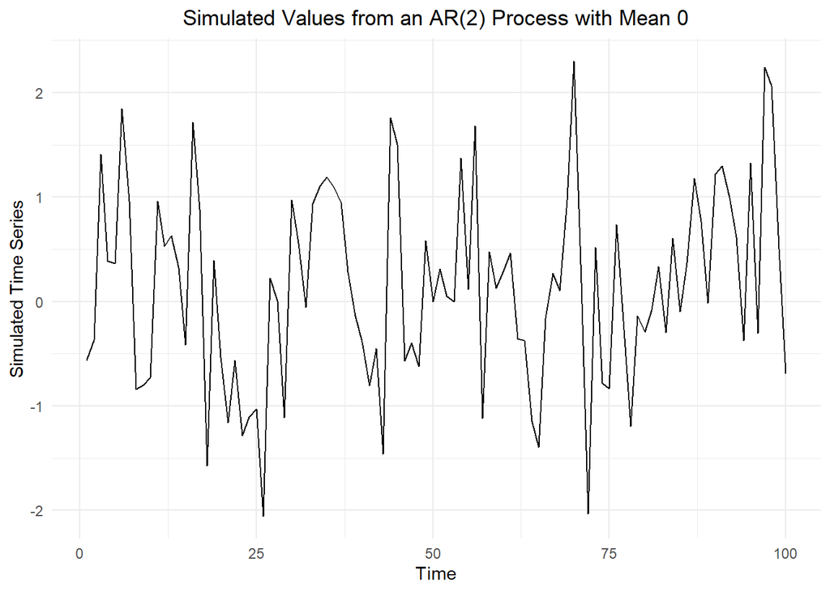

```r
set.seed(123)

n <- 100
alpha0 <- 0
alpha1 <- 0.25
alpha2 <- 0.1
sigma_sqr <- 1

# Generate all random noise
w <- rnorm(n, sd = sqrt(sigma_sqr))

# Place the first two values
x <- rep(0, n)
x[1] <- alpha0 + w[1]
x[2] <- alpha0 + alpha1 * (x[1] - alpha0) + w[2]

# Populate the rest of the series
for (i in 3:n) {
  x[i] <- alpha0 + alpha1 * (x[i-1] - alpha0) + alpha2 * (x[i-2] - alpha0) + w[i]
}

# Bind to a tibble and cast to tsibble at the very end
sim_ts <- tibble(index = 1:n, x = x) |>
  as_tsibble(index = index)

# Plot
autoplot(sim_ts, x) +
  labs(
    x = "Time",
    y = "Simulated Time Series",
    title = paste("Simulated Values from an AR(2) Process with Mean", alpha0)
  ) +
  theme_minimal() +
  theme(
    plot.title = element_text(hjust = 0.5)
  )
```

#### b) Is the AR(2) process stationary? Please use the characteristic equation method and report your results in a table.

**NoteAnswer**

```r
abs(polyroot(c(1, -0.25, -0.1)))
```

```
[1] 2.150368 4.650368
```

Yes it is stationary because the absolute value to the solutions of the characteristic equation are both greater than 1.

#### c) Let R decide how many lags between 1 and 9 to fit the simulated series. Try it a few times. How often were the model parameters inside the estimate’s confidence intervals?

**NoteAnswer**

```r
# Turn simulation into a function for easier use
simulate_ar2 <- function(seed, n) {
  set.seed(seed)

  n <- n
  alpha0 <- 0
  alpha1 <- 0.25
  alpha2 <- 0.1
  sigma_sqr <- 1

  # Generate all random noise
  w <- rnorm(n, sd = sqrt(sigma_sqr))

  # Place the first two values
  x <- rep(0, n)
  x[1] <- alpha0 + w[1]
  x[2] <- alpha0 + alpha1 * (x[1] - alpha0) + w[2]

  # Populate the rest of the series
  for (i in 3:n) {
    x[i] <- alpha0 + alpha1 * (x[i-1] - alpha0) + alpha2 * (x[i-2] - alpha0) + w[i]
  }

  # Bind to a tibble and cast to tsibble at the very end
  sim_ts <- tibble(index = 1:n, x = x) |>
    as_tsibble(index = index)

  # Fit the model
  fit <- sim_ts |>
    model(AR(x ~ order(1:9)))

  # Display
  tidy(fit) |>
    select(!.model) |>
    mutate(
      lower = estimate - 2 * std.error,
      upper = estimate + 2 * std.error
    ) |>
    pander()
}
```

#### Seed 123

```r
simulate_ar2(123, 100)
```

| term | estimate | std.error | statistic | p.value | lower | upper |
| --- | --- | --- | --- | --- | --- | --- |
| ar1 | 0.2588 | 0.09718 | 2.663 | 0.009045 | 0.06441 | 0.4531 |

#### Seed 164

```r
simulate_ar2(164, 100)
```

| term | estimate | std.error | statistic | p.value | lower | upper |
| --- | --- | --- | --- | --- | --- | --- |
| ar1 | 0.1707 | 0.09877 | 1.729 | 0.08705 | -0.0268 | 0.3683 |
| ar2 | 0.0871 | 0.09965 | 0.8741 | 0.3842 | -0.1122 | 0.2864 |
| ar3 | -0.1261 | 0.09811 | -1.286 | 0.2016 | -0.3224 | 0.07008 |

#### Seed 198

```r
simulate_ar2(198, 100)
```

| term | estimate | std.error | statistic | p.value | lower | upper |
| --- | --- | --- | --- | --- | --- | --- |
| ar1 | 0.05133 | 0.09843 | 0.5215 | 0.6032 | -0.1455 | 0.2482 |

We can see from the models above that none of them selected an AR(2) process. With the models above the parameters were usually caught within the confidence interval. However your answers may be different depending on the seeds you set.

#### d) Increase n to 1000. Repeat part c. Did the R routine obtain better estimates?

**NoteAnswer**

#### Seed 123

```r
simulate_ar2(123, 1000)
```

| term | estimate | std.error | statistic | p.value | lower | upper |
| --- | --- | --- | --- | --- | --- | --- |
| ar1 | 0.2192 | 0.03157 | 6.943 | 6.891e-12 | 0.1561 | 0.2823 |
| ar2 | 0.07321 | 0.03157 | 2.319 | 0.02061 | 0.01007 | 0.1364 |

#### Seed 164

```r
simulate_ar2(164, 1000)
```

| term | estimate | std.error | statistic | p.value | lower | upper |
| --- | --- | --- | --- | --- | --- | --- |
| ar1 | 0.2725 | 0.03159 | 8.628 | 2.426e-17 | 0.2094 | 0.3357 |
| ar2 | 0.07254 | 0.03266 | 2.221 | 0.02656 | 0.007225 | 0.1379 |
| ar3 | -0.05026 | 0.03157 | -1.592 | 0.1116 | -0.1134 | 0.01287 |

#### Seed 198

```r
simulate_ar2(198, 1000)
```

| term | estimate | std.error | statistic | p.value | lower | upper |
| --- | --- | --- | --- | --- | --- | --- |
| ar1 | 0.2788 | 0.03152 | 8.844 | 4.126e-18 | 0.2157 | 0.3418 |
| ar2 | 0.1085 | 0.03146 | 3.45 | 0.000585 | 0.0456 | 0.1714 |

The estimates for the parameters have improved. For the models that were AR(2) models we can see that the model parameters are within the confidence interval. With an increase in information, R was able to more accurately identify the model. However one of the models still did not identify that this is an AR(2) process.

#### e) How much trust should you have in R’s model fitting routine when you don’t know what the data generating process is?

**NoteAnswer**

You should excise great caution when using R’s model fitting routine if you do not know the data generating process. R will try to optimize the model, without evaluating the context that lies behind the data producing the model. Due to this, it is up to you the evaluate a series and what model should be used by performing exploratory analysis and gaining domain knowledge about the series being worked on.

### Question 3 - Stationarity and AR(p) fitting (50 points)

A key assumption when fitting AR(p)) models is that the time series data is stationary. Stationarity ensures that the statistical properties of the series remain constant over time, so our estimates of the mean, variance, and temporal relationships are valid. Non-stationary data, characterized by trends or changing mean and variance, can lead to unreliable parameter estimates and inaccurate forecasts when using AR(p) models. To address non-stationarity, a common solution is to apply differencing, particularly first differencing. By employing first differencing, the non-stationary series can be transformed into a stationary form, allowing for the application of AR(p) models with more confidence and accuracy.

#### a) Plot the Dollar-Euro Exchange Rate series, it’s correlogram, and a partial correlogram. Is the series stationary?

**NoteAnswer**

**Combined**

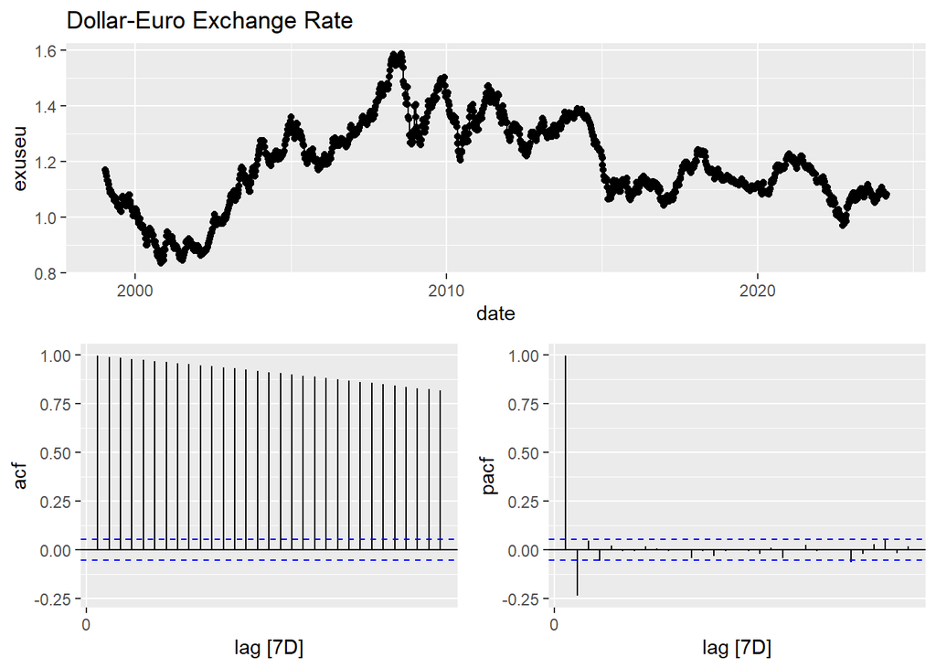

```r
us_ts <- exuseu |>
  mutate(date = mdy(date))|>
  as_tsibble(index = date)

gg_tsdisplay(us_ts, plot_type = "partial") +
  labs(
    title = "Dollar-Euro Exchange Rate"
  )
```

**Separate**

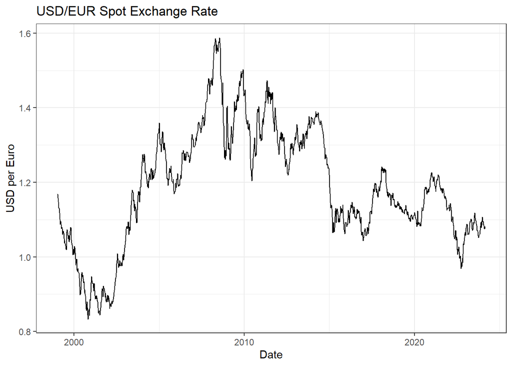

```r
autoplot(us_ts) +
  labs(
    title = "USD/EUR Spot Exchange Rate",
    x = "Date",
    y = "USD per Euro"
  ) +
  theme_bw()
```

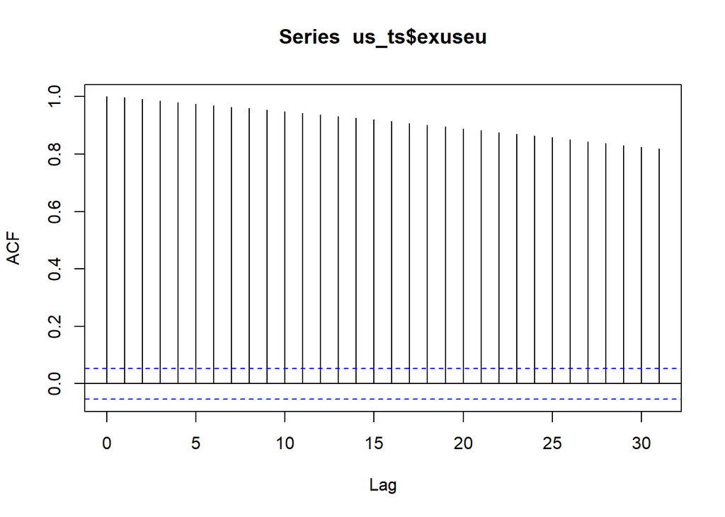

```r
acf(us_ts$exuseu)
```

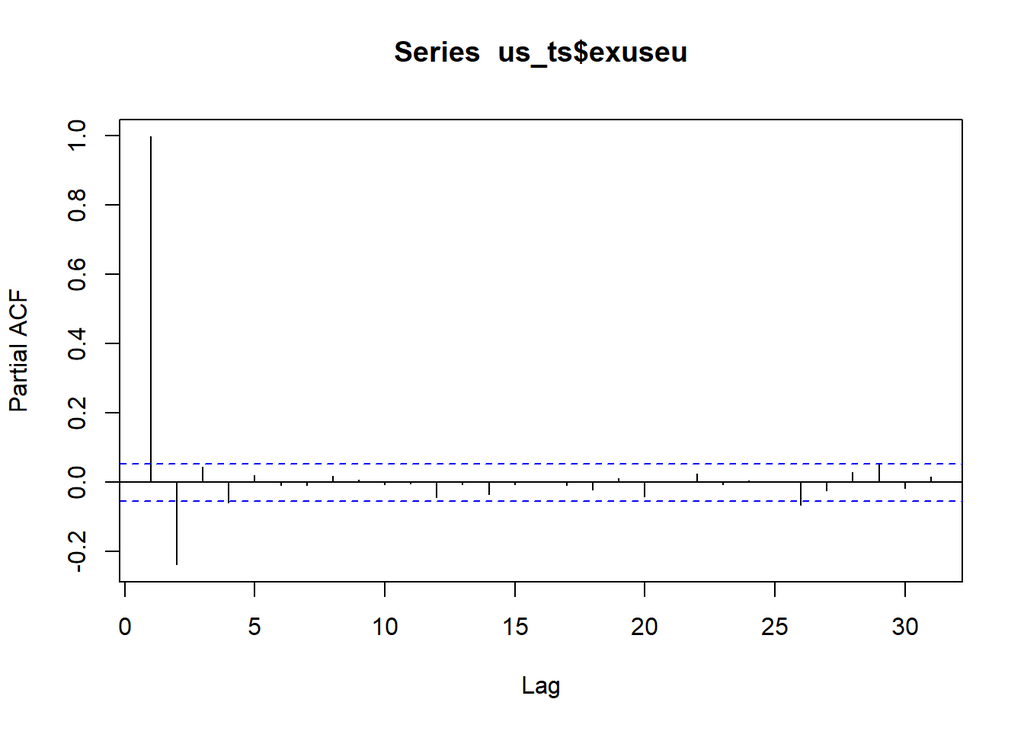

```r
pacf(us_ts$exuseu)
```

#### b) Fit an AR(p) model to the data by letting R choose how many lags to use? Please report your results in a table.

**NoteAnswer**

```r
fit_ar <- us_ts |>
  model(AR(exuseu ~ order(1:9)))

tidy(fit_ar) |>
  mutate(
    lower = estimate - 2 * std.error,
    upper = estimate + 2 * std.error
  )
```

```
# A tibble: 5 × 8
  .model          term  estimate std.error statistic   p.value    lower    upper
  <chr>           <chr>    <dbl>     <dbl>     <dbl>     <dbl>    <dbl>    <dbl>
1 AR(exuseu ~ or… cons…  0.00480   0.00261      1.84 6.64e-  2 -4.25e-4  0.0100
2 AR(exuseu ~ or… ar1    1.26      0.0276      45.5  4.54e-272  1.20e+0  1.31
3 AR(exuseu ~ or… ar2   -0.326     0.0442      -7.37 2.94e- 13 -4.14e-1 -0.238
4 AR(exuseu ~ or… ar3    0.129     0.0442       2.93 3.48e-  3  4.10e-2  0.218
5 AR(exuseu ~ or… ar4   -0.0640    0.0276      -2.32 2.05e-  2 -1.19e-1 -0.00884
```

#### c) Is the fitted model stationary? Would you use the fitted model as the basis for forecasting?

**NoteAnswer**

```r
abs(polyroot(c(1, -1.257, 0.326, -0.129, 0.064)))
```

```
[1] 1.005448 2.624603 2.624603 2.255970
```

The fitted model is stationary. However this model is unfit to be used for forecasting as the underlying data appears to be non-stationary. This model also does not follow what we observe from the partial correlogram and therefore needs more scutiny.

#### d) Take the first-difference of the Dollar-Euro Exchange Rate series.

**NoteAnswer**

```r
us_ts <- us_ts |>
  mutate(diff = difference(exuseu))

us_ts |>
  select(date, diff) |>
  head()
```

```
# A tsibble: 6 x 2 [7D]
  date            diff
  <date>         <dbl>
1 1999-01-08 NA
2 1999-01-15 -0.00750
3 1999-01-22 -0.00260
4 1999-01-29 -0.0108
5 1999-02-05 -0.0166
6 1999-02-12 -0.001000
```

#### e) Plot the differenced series, it’s correlogram, and a partial correlogram. Is the series stationary?

**NoteAnswer**

**Combined**

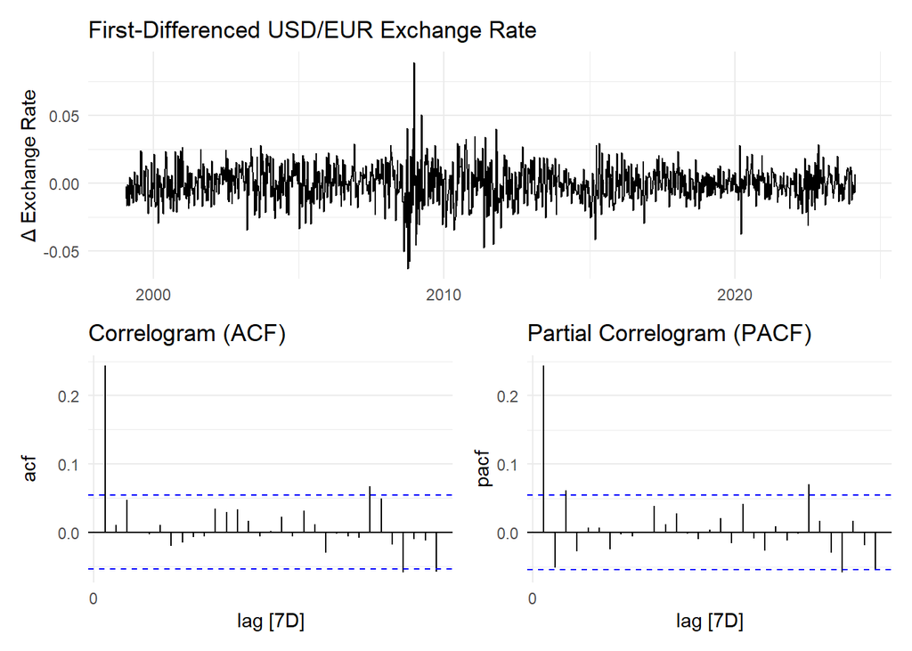

```r
diff_plot <- autoplot(us_ts, diff) +
  labs(
    title = "First-Differenced USD/EUR Exchange Rate",
    x = NULL,
    y = "Δ Exchange Rate"
  ) +
  theme_minimal()

diff_acf <- us_ts |>
  ACF(diff) |>
  autoplot() +
  labs(
    title = "Correlogram (ACF)"
  ) +
  theme_minimal()

diff_pacf <- us_ts |>
  PACF(diff) |>
  autoplot() +
  labs(
    title = "Partial Correlogram (PACF)"
  ) +
  theme_minimal()

diff_plot / (diff_acf + diff_pacf)
```

**Separate**

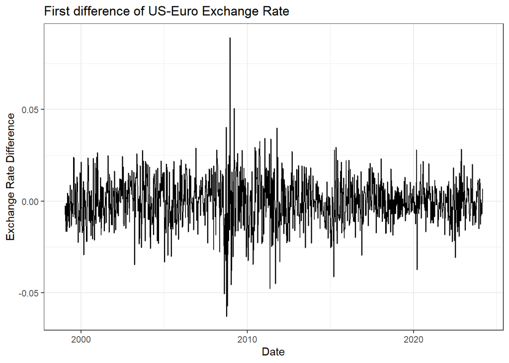

```r
ggplot(data = us_ts, aes(x = date, y = diff)) +
  geom_line() +
  labs(
    x = "Date",
    y = "Exchange Rate Difference",
    title = "First difference of US-Euro Exchange Rate"
  ) +
  theme_bw()
```

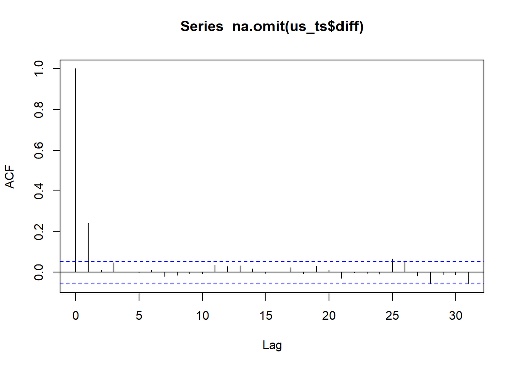

```r
acf(na.omit(us_ts$diff))
```

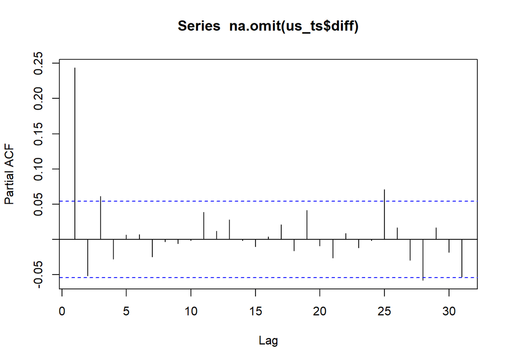

```r
pacf(na.omit(us_ts$diff))
```

By taking a first difference of the series, we get a series that appears to be stationary. When evaluating the correlogram we no longer see the same decay that we originally saw as lags increased.

#### f) Fit an AR(p) model to the data by letting R choose how many lags to use? Please report your results in a table.

**NoteAnswer**

```r
fit_ar <- na.omit(us_ts) |>
  model(AR(diff ~ order(1:9)))

tidy(fit_ar) |>
  mutate(
    lower = estimate - 2 * std.error,
    upper = estimate + 2 * std.error
  )
```

```
# A tibble: 3 × 8
  .model            term  estimate std.error statistic  p.value    lower   upper
  <chr>             <chr>    <dbl>     <dbl>     <dbl>    <dbl>    <dbl>   <dbl>
1 AR(diff ~ order(… ar1     0.259     0.0276      9.39 2.61e-20  0.204    0.314
2 AR(diff ~ order(… ar2    -0.0675    0.0284     -2.37 1.78e- 2 -0.124   -0.0106
3 AR(diff ~ order(… ar3     0.0614    0.0276      2.23 2.62e- 2  0.00621  0.117
```

#### g) Is the fitted model stationary? Would you use the fitted model as the basis for forecasting?

**NoteAnswer**

```r
abs(polyroot(c(1, -0.259, 0.067, -0.061)))
```

```
[1] 2.317880 2.659436 2.659436
```

### Rubric

[output not shown]